# nycflights13数据预处理

王思雨

2017年10月29日

## 一、数据的准备

### 1、R包的加载

```r
library(maps)
library(ggplot2)
library(ggthemes)
library(plyr)
library(dplyr)
library(nycflights13)
library(lubridate)
library(devtools)
library(REmap)  #读取所在数据收集中应用的包
load("D:/大数据作业/数据预处理/数据预处理第一次课/.RData")
```

## 2、数据的读取与准备

进行数据的导入处理以及数据的完成性检查，并利用dplyr将数据处理成友好整洁数据

```r
data(flights)
head(flights)
```

```
## # A tibble: 6 x 19
##    year month   day dep_time sched_dep_time dep_delay arr_time
##   <int> <int> <int>    <int>          <int>     <dbl>    <int>
## 1  2013     1     1      517            515         2      830
## 2  2013     1     1      533            529         4      850
## 3  2013     1     1      542            540         2      923
## 4  2013     1     1      544            545        -1     1004
## 5  2013     1     1      554            600        -6      812
## 6  2013     1     1      554            558        -4      740
## # ... with 12 more variables: sched_arr_time <int>, arr_delay <dbl>,
## #   carrier <chr>, flight <int>, tailnum <chr>, origin <chr>, dest <chr>,
## #   air_time <dbl>, distance <dbl>, hour <dbl>, minute <dbl>,
## #   time_hour <dttm>
```

```r
## 将nycflights13包中过长过大的数据集转换为显示更友好的 tbl_df 类型:
flights_df <- tbl_df(flights)
airports_df <- tbl_df(airports)
airlines_df <- tbl_df(airlines)
weather_df <- tbl_df(weather)
planes_df <- tbl_df(planes)
```

## 二、Homework2作业题

### 1、对比dep_time，sched_dep_time与dep_delay变量

定义函数将不规范的时间数据dep_time，sched_dep_time进行标准化为Date数据

```r
make_datetime_100 <- function(year, month, day, time) {
    make_datetime(year, month, day, time%/%100, time%%100)
    # 对time进行操作取整取余化为标准时间数据
}
```

从flights_df数据集中选取变量并对其进行一系列操作构成flights_dt

```r
flights_dt <- flights_df %>% dplyr::filter(!is.na(dep_time), !is.na(sched_dep_time),
    !is.na(dep_delay)) %>% dplyr::mutate(dep_time = make_datetime_100(year,
    month, day, dep_time)) %>% dplyr::mutate(sched_dep_time = make_datetime_100(year,
    month, day, sched_dep_time)) %>% dplyr::select(dep_time, sched_dep_time,
    dep_delay)
head(flights_dt)
```

```
## # A tibble: 6 x 3
##              dep_time      sched_dep_time dep_delay
##                <dttm>              <dttm>     <dbl>
## 1 2013-01-01 05:17:00 2013-01-01 05:15:00         2
## 2 2013-01-01 05:33:00 2013-01-01 05:29:00         4
## 3 2013-01-01 05:42:00 2013-01-01 05:40:00         2
## 4 2013-01-01 05:44:00 2013-01-01 05:45:00        -1
## 5 2013-01-01 05:54:00 2013-01-01 06:00:00        -6
## 6 2013-01-01 05:54:00 2013-01-01 05:58:00        -4
```

比较利用数据dep_time-sched_dep_time是否与所记录的dep_delay变量相同

```r
my_delay = (as.numeric(flights_dt$dep_time) - as.numeric(flights_dt$sched_dep_time))/60
tmp = my_delay == flights_dt$dep_delay
table(tmp)
```

```
## tmp
##  FALSE   TRUE
##   1207 327314
```

```r
## 查看是否数据全部为TURE
```

```r
for (i in c(which(my_delay != flights_dt$dep_delay))) {
    flights_dt[i, 1] <- flights_dt[i, 1] + 86400
}
# 将数据调整后
my_delay = (as.numeric(flights_dt$dep_time) - as.numeric(flights_dt$sched_dep_time))/60
tmp = my_delay == flights_dt$dep_delay
table(tmp)
```

```
## tmp
##   TRUE
## 328521
```

此时发现数据全部为TRUE，可以说变量之间是全部相等的,而且还修正了了数据。

### 2、一天中不同时间点的平均延误时间

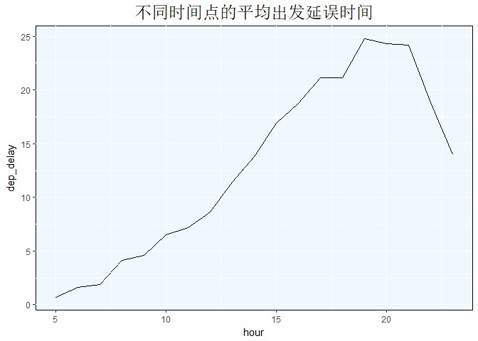

```r
mean_average = aggregate(dep_delay ~ hour, flights_df, mean)
ggplot(mean_average, aes(x = hour, y = dep_delay)) + geom_line() + ggtitle("不同时间点的平均出发延误时间") +
    theme(plot.title = element_text(hjust = 0.5, family = "myFont", size = 18,
        color = "black"), panel.background = element_rect(fill = "aliceblue",
        color = "black"))
```

### 3、最小化飞机延误的概率，选择出行日

计算延误概率，首先进行是否有延误进行判断

```r
result_3 <- flights_df %>% dplyr::filter(!is.na(time_hour), !is.na(dep_delay)) %>%
    dplyr::select(time_hour, dep_delay) %>% dplyr::mutate(delay_bool = as.integer((dep_delay >
    0) * 1), my_weekday = weekdays(time_hour)) %>% # 对是否存在延误进行判断
dplyr::group_by(my_weekday) %>% dplyr::summarize(pro_delay = mean(delay_bool)) %>%
    # 计算出延误概率
dplyr::arrange(pro_delay)
```

显示3题结果，从延误概率来看，周六进行出行的被延误率小

```r
result_3
```

```
## # A tibble: 7 x 2
##   my_weekday pro_delay
##        <chr>     <dbl>
## 1     星期六 0.3484693
## 2     星期二 0.3643394
## 3     星期三 0.3726718
## 4     星期日 0.3831256
## 5     星期一 0.4011522
## 6     星期五 0.4254415
## 7     星期四 0.4317364
```

```r
# 所以选择周六出行被延误的概率小
```

### 4、计算每个目的地机场的平均延误时间

```r
result_4<-
  inner_join(flights_df,airports_df,c('dest'='faa')) %>%
  #内部合并flights_df与airports_df只合并交集
  select(dest,arr_delay)%>%
   na.omit()%>%    #去除空值
  dplyr::mutate(delay_bool=as.integer((arr_delay>0)*1))%>%
  #计算平均延误时间所以将提前到达和未延误的行去除掉
  dplyr::mutate(delay_time=arr_delay*delay_bool)%>%
  #计算所有的航班延误时间，提前和未延误的记为零
  group_by(dest)%>%
  summarize(mean_delay=mean(delay_time))
```

显示每个目的地机场的平均延误时间

```r
result_4  #显示每个目的地机场的平均延误时间
```

```
## # A tibble: 100 x 2
##     dest mean_delay
##    <chr>      <dbl>
##  1   ABQ   17.66535
##  2   ACK   11.26515
##  3   ALB   22.91866
##  4   ANC    7.75000
##  5   ATL   17.83566
##  6   AUS   16.56574
##  7   AVL   14.06513
##  8   BDL   16.87621
##  9   BGR   19.38547
## 10   BHM   27.01487
## # ... with 90 more rows
```

构造绘制地图数据集tmp

```r
tmp <- inner_join(flights_df, airports_df, c(dest = "faa")) %>% select(dest,
    lon, lat, arr_delay) %>% na.omit() %>% dplyr::mutate(delay_bool = as.integer((arr_delay >
    0) * 1)) %>% dplyr::mutate(delay_time = arr_delay * delay_bool) %>% group_by(dest) %>%
    summarize(lon = max(lon), lat = max(lat), mean_delay = mean(delay_time))  #构造地图变量
```

#### 1)交互式地图

此地图可以显示出普通地图中没有的夏威夷和阿拉斯加州，结果无法显示在Rmarkdown，但是付在作业中

```r
tmp <- data.frame(tmp)
remapH(tmp[, -1], maptype = "world", color = "blue", minAlpha = 0.3, opacity = 1)
```

```
## Save img as: C:\Users\BOKKIN~1\AppData\Local\Temp\RtmpMHAp8W/ID_20171031014238_1189.html
```

#### 2)ggplot地图

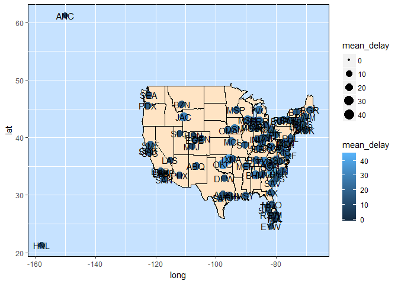

```r
states <- map_data("state")
p <- ggplot() + geom_polygon(data = states, mapping = aes(long, lat, group = group),
    fill = "bisque1", color = "black")
p <- p + theme(plot.title = element_text(hjust = 0.5, family = "myFont", size = 18,
    color = "black"), panel.background = element_rect(fill = "slategray1", color = "black"))
p + geom_point(mapping = aes(x = lon, y = lat, size = mean_delay, color = mean_delay),
    data = tmp) + geom_text(mapping = aes(x = tmp$lon, y = tmp$lat, label = tmp$dest))
```

#### 3)ggplot地图

点状地图不能很好的直观的反映分布各机场延误时间的分布，只能在颜色上观测，但柱状地图则可以

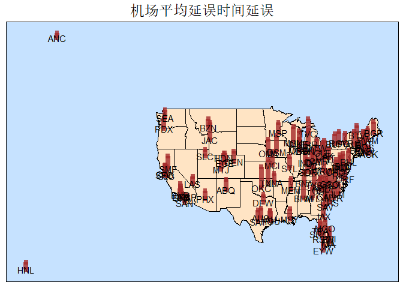

```r
p <- ggplot() + geom_polygon(data = states, mapping = aes(long, lat, group = group),
    fill = "bisque1", color = "black")
p <- p + geom_errorbar(mapping = aes(x = lon, ymin = lat, ymax = lat + mean_delay *
    0.1), data = tmp, colour = "brown", size = 3, width = 1, alpha = 0.8)
p + geom_text(mapping = aes(x = tmp$lon, y = tmp$lat, label = tmp$dest)) + theme(axis.title = element_blank(),
    axis.text = element_blank(), axis.ticks = element_blank(), panel.grid = element_blank()) +
    ggtitle("机场平均延误时间延误") + theme(plot.title = element_text(hjust = 0.5,
    family = "myFont", size = 18, color = "black"), panel.background = element_rect(fill = "slategray1",
    color = "black"))
```

### 5、研究飞机的使用寿命与延误情况之间关系

计算飞机的使用寿命和延误情况，不能单纯的计算飞机的延误时间总和，因为各个飞机的执行任务的次数不同，所以导致执行任务多的飞机总时间较长，所以应该对飞机的飞行平均的到达延误时间进行对比。

```r
fli_pla_df<-
  inner_join(flights_df,planes_df,c('tailnum'='tailnum')) %>%
  select(arr_delay,tailnum,year.x,year.y)%>%
  na.omit()%>%
  dplyr::mutate(delay_bool=as.integer((arr_delay>0)*1))%>%
  dplyr::mutate(delay_time=arr_delay*delay_bool,use_year=year.x-year.y)%>%
  group_by(tailnum)%>%
  summarize(mean_delay=mean(delay_time),use_year=max(use_year))%>%   #计算平均每一次的delay
  arrange(desc(use_year))
cor(fli_pla_df$use_year,fli_pla_df$mean_delay)
```

```
## [1] -0.02159948
```

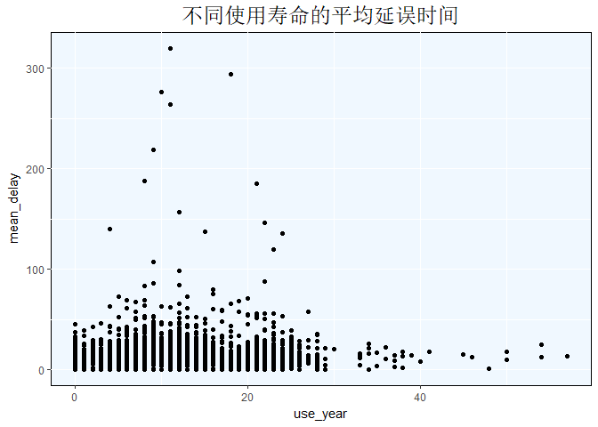

```r
#计算相关系数,相关性很小，甚至成负相关，并无明显关系
ggplot(fli_pla_df,aes(x=use_year,y=mean_delay))+geom_point()+ggtitle('不同使用寿命的平均延误时间') +theme(plot.title = element_text(hjust = 0.5, family="myFont", size=18,color="black"),panel.background=element_rect(fill='aliceblue',color='black'))
```

```r
#从图中可以看到飞机的使用寿命与延误情况之间并无明显相关关系
```